# 11일차

```python
import pandas as pd
from sklearn.tree import DecisionTreeClassifier as dt

df = pd.read_csv('test2_modify.csv')

label = 'IsCanceled'
features = ['LeadTime', 'ArrivalDateYear', 'ArrivalDateWeekNumber',
       'ArrivalDateDayOfMonth', 'StaysInWeekendNights', 'StaysInWeekNights',
       'Adults', 'Children', 'Babies', 'IsRepeatedGuest',
       'PreviousCancellations', 'PreviousBookingsNotCanceled',
       'BookingChanges', 'DaysInWaitingList', 'ADR',
       'TotalOfSpecialRequests', 'Day_Stay',
       'Foreigner', 'Country_Ratio', 'car_yes', 'RA_Changed']

train, test = df[0::2], df[1::2]
train, test = train.reset_index(), test.reset_index()

X_train, y_train = train[features], train[label]
X_test, y_test = test[features], test[label]

model = dt(max_depth=5)
model.fit(X_train, y_train)
```

```
DecisionTreeClassifier(max_depth=5)
```

```python
model.predict(X_test)
```

```
array([0, 0, 1, ..., 0, 0, 0], dtype=int64)
```

```python
y_test
```

```
0        0
1        0
2        1
3        0
4        0
        ..
19793    0
19794    0
19795    0
19796    0
19797    0
Name: IsCanceled, Length: 19798, dtype: int64
```

```python
for_plot = pd.DataFrame()
for_plot['predict'] = model.predict(X_test)
for_plot['actual'] = y_test
for_plot
```

|  | predict | actual |
| --- | --- | --- |
| 0 | 0 | 0 |
| 1 | 0 | 0 |
| 2 | 1 | 1 |
| 3 | 1 | 0 |
| 4 | 1 | 0 |
| ... | ... | ... |
| 19793 | 0 | 0 |
| 19794 | 0 | 0 |
| 19795 | 0 | 0 |
| 19796 | 0 | 0 |
| 19797 | 0 | 0 |

19798 rows × 2 columns

## 혼동행렬(Confusion Matrix)

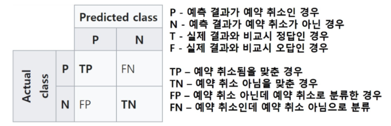

#### 자주 사용하는 분류 문제의 평가지표

1. accuracy: 전체 중에서 맞춘 비율
- acc = (TP + TN) / (TP + TN + FN + FP)
1. precision: T 라고 분류한 것 중에서 실제 T인 것의 비율
- prec = TP / (TP + FP)
1. recall: 실제 T 인 것 중에서 모델이 T라고 예측한 것의 비율
- recall = TP / (TP + FN)
- ex) 실제 날씨가 맑은 날 중에서 모델이 맑다고 예측한 비율을 나타낸 지표
- sensitivity, hit rate
1. fall-out: 실제 F인 데이터 중에서 모델이 T라고 예측한 비율
- fall = FP / (FP + TN)

#### 언제 accuracy 대신 prec 과 recall 등이 고려될까?

- 클래스 불균형 문제가 발생할 때 acc의 의미가 떨어짐

#### prec, recall의 차이

- ex) 화재경보(불이 남: 1, 안 남: 0)
- FP는 불 났다고 판단했으나 불 안남, FN는 불 안 났다고 판단했으나 불 남
- 경중의 차이가 큼 -> FN에 중점을 둬야함
- ex) 스팸메일 분류(스팸: 1, 스팸 x: 0)
- FP는 스팸이라 판단했으나 스팸 아님, FN는 스팸이 아니라 판단했으나 스팸임
- 중요한 메일이 오기로 했는데 스팸으로 분류되면 확인 못함 -> FP
- ex) 환자 검진(병: 1, 병x: 0)
- ex) 금융 사기 탐지(사기: 1, 아니: 0)
- ex) 게임 어뷰저 분류(어뷰저: 1, 아니: 0)

```python
from sklearn.metrics import confusion_matrix as cm

TN, FP, FN, TP = cm(for_plot['actual'], for_plot['predict']).ravel()
print(TN, FP, FN, TP)
```

```
13424 849 2490 3035
```

```python
acc = (TP + TN) / (TP + TN + FN + FP)
prec = TP / (TP + FP)
recall = TP / (TP + FN)
print(acc, prec, recall)
```

```
0.831346600666734 0.7814109165808445 0.5493212669683258
```

## ROC_Curve

- 분류 모형 성능을 시각화
- recall-fallout의 변화를 시각화
- AUC: 곡선 아래의 면적

```python
from sklearn.tree import DecisionTreeClassifier as dt
from sklearn.ensemble import RandomForestClassifier as rf
from sklearn.ensemble import GradientBoostingClassifier as gb

m1, m2, m3 = dt(), rf(), gb()
m1.fit(X_train, y_train)
m2.fit(X_train, y_train)
m3.fit(X_train, y_train)
```

```
GradientBoostingClassifier()
```

```python
m2.predict_proba(X_test)
```

```
array([[0.83, 0.17],
       [0.81, 0.19],
       [0.3 , 0.7 ],
       ...,
       [1.  , 0.  ],
       [0.87, 0.13],
       [0.67, 0.33]])
```

```python
r1 = pd.DataFrame(m1.predict_proba(X_test), columns=['neg', 'pos'])
r2 = pd.DataFrame(m2.predict_proba(X_test), columns=['neg', 'pos'])
r3 = pd.DataFrame(m3.predict_proba(X_test), columns=['neg', 'pos'])
r3
```

|  | neg | pos |
| --- | --- | --- |
| 0 | 0.494244 | 0.505756 |
| 1 | 0.816796 | 0.183204 |
| 2 | 0.288396 | 0.711604 |
| 3 | 0.370010 | 0.629990 |
| 4 | 0.361432 | 0.638568 |
| ... | ... | ... |
| 19793 | 0.605018 | 0.394982 |
| 19794 | 0.605018 | 0.394982 |
| 19795 | 0.551790 | 0.448210 |
| 19796 | 0.551790 | 0.448210 |
| 19797 | 0.633745 | 0.366255 |

19798 rows × 2 columns

```python
from sklearn.metrics import roc_curve
import matplotlib.pyplot as plt

x1, y1, _ = roc_curve(y_test, r1['pos'])
print(x1)
print(y1)
```

```
[0.         0.11069852 0.11090871 0.1111189  0.11118896 0.11301058
 0.11343095 0.11364114 0.11490226 0.11511245 0.11553282 1.        ]
[0.         0.75909502 0.75945701 0.76       0.76054299 0.76343891
 0.76343891 0.76361991 0.76434389 0.76452489 0.76506787 1.        ]
```

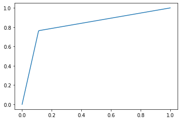

```python
plt.plot(x1, y1, label='DecisionTree')
```

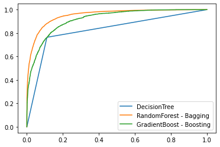

```python
x2, y2, _ = roc_curve(y_test, r2['pos'])
x3, y3, _ = roc_curve(y_test, r3['pos'])
plt.plot(x1, y1, label='DecisionTree')
plt.plot(x2, y2, label='RandomForest - Bagging')
plt.plot(x3, y3, label='GradientBoost - Boosting')
plt.legend()
```

#### ROC curve는 어떻게 그려질까?

- 확신의 정도와 실제 정답을 이용해 y축을 recall, x축을 fall-out 좌표로 이용
- 전부 true라 예측하면? -> recall: 1.0, fallout: 1.0 -> (1, 1) 좌표
- 전부 false라 예측하면? -> recall: 0.0, fallout: 0.0 -> (0, 0) 좌표
- 판단 기준(threshold)을 0~100%까지 조금씩 바꾸면서 그때마다 혼동행렬 획득 -> 평가지표 값을 산출
- ex) 판단 기준을 0, 10, 20, .... 100%으로 총 11번 다르게 한다면? -> 혼동행렬도 11개 나오고, 좌표 평면에 점을 11개 찍을 수 있음 -> 이 점들을 이어 그리면 ROC_Curve 완성

## Hyperparameter-Tuning

- 알고리즘의 옵션을 조정해 성능을 튜닝하는 방법
- 최적의 옵션 값을 찾아 알고리즘 성능을 극대화시키는 방법

```python
model = rf()
model.fit(X_train, y_train)
for_plot['predict'] = model.predict(X_test)
for_plot['actual'] = y_test

TN, FP, FN, TP = cm(for_plot['actual'], for_plot['predict']).ravel()
recall = TP / (TP + FN)
print(recall)
```

```
0.7831674208144797
```

```python
model = rf(max_depth=10, max_features=0.9)
model.fit(X_train, y_train)
for_plot['predict'] = model.predict(X_test)
for_plot['actual'] = y_test

TN, FP, FN, TP = cm(for_plot['actual'], for_plot['predict']).ravel()
recall = TP / (TP + FN)
print(recall)
```

```
0.7042533936651584
```

```python
def scorer(model):
    model.fit(X_train, y_train)
    for_plot = pd.DataFrame()
    for_plot['predict'] = model.predict(X_test)
    for_plot['actual'] = y_test

    TN, FP, FN, TP = cm(for_plot['actual'], for_plot['predict']).ravel()
    recall = TP / (TP + FN)
    return recall
```

```python
model = rf(max_depth=7, max_features=0.6)
scorer(model)
```

```
0.6573755656108597
```

#### 접근법 3가지

- Grid-Search: 격자 모양으로 찾기
- Random-Search: 무작위 조합으로 찾기(나름 시스템이 있음)
- Optimizer: 수학을 기반으로 함수의 정의역이 옵션, 치역이 평가지표

```python
md_ls = [3, 5, 7, 9, 11, 13, 15, 17]
mf_ls = [0.1, 0.3, 0.5, 0.7, 0.9]
all_scores = []

for md in md_ls:
    for mf in mf_ls:
        model = rf(max_depth=md, max_features=mf, n_jobs=-1)
        all_scores.append({'recall': scorer(model), 'md':md, 'mf':mf})

hyper_df = pd.DataFrame(all_scores)
hyper_df.sort_values(by='recall', ascending=False)
```

|  | recall | md | mf |
| --- | --- | --- | --- |
| 39 | 0.794751 | 17 | 0.9 |
| 38 | 0.793122 | 17 | 0.7 |
| 37 | 0.789502 | 17 | 0.5 |
| 34 | 0.776652 | 15 | 0.9 |
| 33 | 0.776471 | 15 | 0.7 |
| 32 | 0.769050 | 15 | 0.5 |
| 36 | 0.768326 | 17 | 0.3 |
| 29 | 0.748416 | 13 | 0.9 |
| 28 | 0.748235 | 13 | 0.7 |
| 31 | 0.745339 | 15 | 0.3 |
| 27 | 0.738100 | 13 | 0.5 |
| 26 | 0.719457 | 13 | 0.3 |
| 24 | 0.716561 | 11 | 0.9 |
| 23 | 0.714389 | 11 | 0.7 |
| 22 | 0.710588 | 11 | 0.5 |
| 21 | 0.703167 | 11 | 0.3 |
| 35 | 0.699367 | 17 | 0.1 |
| 18 | 0.693756 | 9 | 0.7 |
| 19 | 0.687783 | 9 | 0.9 |
| 17 | 0.687240 | 9 | 0.5 |
| 16 | 0.670950 | 9 | 0.3 |
| 30 | 0.670407 | 15 | 0.1 |
| 14 | 0.651222 | 7 | 0.9 |
| 13 | 0.650317 | 7 | 0.7 |
| 12 | 0.649593 | 7 | 0.5 |
| 25 | 0.644706 | 13 | 0.1 |
| 11 | 0.637285 | 7 | 0.3 |
| 9 | 0.633846 | 5 | 0.9 |
| 8 | 0.633484 | 5 | 0.7 |
| 7 | 0.605249 | 5 | 0.5 |
| 20 | 0.601448 | 11 | 0.1 |
| 4 | 0.601267 | 3 | 0.9 |
| 6 | 0.592760 | 5 | 0.3 |
| 3 | 0.592217 | 3 | 0.7 |
| 2 | 0.584977 | 3 | 0.5 |
| 15 | 0.576109 | 9 | 0.1 |
| 1 | 0.574118 | 3 | 0.3 |
| 10 | 0.508778 | 7 | 0.1 |
| 5 | 0.313665 | 5 | 0.1 |
| 0 | 0.051041 | 3 | 0.1 |

```python
import time

target_time = 5
t0 = time.time()

while True:
    t1 = time.time() - t0
    if t1 > target_time:
        break

print('반복끝')
```

```
반복끝
```

```python
from random import randint

randint(1, 999) / 1000
```

```
0.062
```

```python
target_time = 600
t0 = time.time()

while True:
    t1 = time.time()
    if t1 > target_time:
        break

    md = randint(15, 30)
    mf = randint(1, 999) / 1000
    model = rf(max_depth=md, max_features=mf, n_jobs=-1)
    all_scores.append({'recall': scorer(model), 'md':md, 'mf':mf})

hyper_df = pd.DataFrame(all_scores)
hyper_df.sort_values(by='recall', ascending=False).head(10)
```

[output not shown]